# Network Visualization of X-space

# 1. Visualize the space as a network

In this section, we will practice how to visualize the X-spaces with traditional network-based method.

The sections are organized according to our viz-pipeline:

- Data collection and metric calculation (load previous results)
- Extract the informative part of relation: mst + high proximity
- Layout generation: force-layout
- Cluster generation: community detection
- Aesthetic mapping: desired property -> visual elements
  - Whole network
  - Portfolio

In this tutorial, we will mainly use the `tidyverse` packages for data manipulations and `igraph` for network creation and visualization. Install and load all necessary packages:

```r
package_list <-
  c(
    "tidyverse",
    "igraph",
    "viridis",
    "umap",
    "reticulate",
    "tidygraph",
    "ggraph"
  )
# Check if packages are already installed, otherwise install them
to_install <-
  package_list[!(package_list %in% installed.packages()[, "Package"])]
if (length(to_install)) {
  install.packages(to_install)
}
library(tidyverse)
library(igraph)
library(viridis)
library(tidygraph)
library(ggraph)
library(umap)
```

## Data collection and metric calculation (load previous results)

In this part, we need to get a proximity matrix or dataframe as the input of following steps. If you are doing your own research on some kind of spaces, you need to clean and transform your raw data, and assess the relatedness with a similarity or distance metric.

Here we will use a pre-calculated proximity dataframe from the Atlas of Economic complexity. You can get this dataframe by following Matte’s tutorial, or use the output of `economiccomplexity` package.

```r
## Load the data from atlas of economic complexity
if (!file.exists("hs92_proximities.csv")) {
  download.file("http://intl-atlas-downloads.s3.amazonaws.com/atlas_2_16_6/hs92_proximities.csv", "hs92_proximities.csv")
}
## specify the first two columns of product code as character and the 3rd column proximity as numeric
proxdf <- read_csv("hs92_proximities.csv", col_types = "ccn")
head(proxdf)
```

| commoditycode_1 | commoditycode_2 | proximity |
| --- | --- | --- |
| 0101 | 0101 | 0.000000 |
| 0101 | 0102 | 0.277778 |
| 0101 | 0103 | 0.352941 |
| 0101 | 0104 | 0.260870 |
| 0101 | 0105 | 0.296296 |
| 0101 | 0106 | 0.200000 |

Let’s first examine the distribution of proximity metric, which helps us decide in extracting the informative parts.

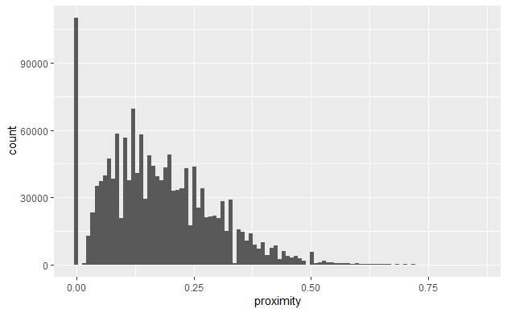

```r
ggplot(proxdf, aes(x = proximity)) +
  geom_histogram(bins = 100)
```

We observed that proximity is right-skewed. There are a few observations in the right tail with high proximity, which is good: we can cover the informative part without introducing many links.

Load the names of hs code so that we could use for annotation and analysis.

```r
if (!file.exists("hs_product.zip")) {
  download.file("http://intl-atlas-downloads.s3.amazonaws.com/17.0/hs_product.zip", "hs_product.zip")
}
hsdf <- read_csv("hs_product.zip", col_types = "c")
head(hsdf)
```

| product_id | hs_product_code | hs_product_name_short_en |
| --- | --- | --- |
| 0 | 0 | Textiles |
| 1 | 1 | Agriculture |
| 2 | 2 | Stone |
| 3 | 3 | Minerals |
| 4 | 4 | Metals |
| 5 | 5 | Chemicals |

Let’s only keep the product names used in the calculation of proximity (1240 out of 6396):

```r
hsdf$hs_product_code %>% n_distinct()
```

```
[1] 6396
```

```r
proxdf$commoditycode_1 %>% n_distinct()
```

```
[1] 1240
```

```r
nodedf <- hsdf %>%
  filter(hs_product_code %in% proxdf$commoditycode_1) %>%
  select(hs_product_code, hs_product_name_short_en) %>%
  arrange(hs_product_code)
head(nodedf)
```

| hs_product_code | hs_product_name_short_en |
| --- | --- |
| 0101 | Horses |
| 0102 | Bovine |
| 0103 | Swine |
| 0104 | Sheep |
| 0105 | Fowl |
| 0106 | Other live animals |

### (Optional) visualize the raw proximity matrix

If your data is a proximity dataframe, you could visualize in a matrix view as a heatmap with the `geom_tile` function. The natural sorting of product codes usually exhibits a block structure:

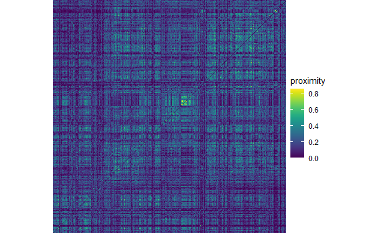

```r
ggplot(proxdf, aes(commoditycode_1, commoditycode_2, fill = proximity)) +
  geom_raster() +
  coord_equal() +
  scale_fill_viridis() +
  theme_void()
```

## Create graph and extract the backbone

Given the proximity dataframe, we could convert them into network object in igraph using the node dataframe and proximity/edge dataframe. By default, it will create an undirected network.

```r
fullgraph <- graph_from_data_frame(proxdf, directed = FALSE, vertices = nodedf) %>%
  simplify(remove.multiple = TRUE, remove.loops = TRUE, edge.attr.comb = "first")
fullgraph
```

```
IGRAPH a074b9f UN-- 1240 768180 --
+ attr: name (v/c), hs_product_name_short_en (v/c), proximity
| (e/n)
+ edges from a074b9f (vertex names):
 [1] 0101--0102 0101--0103 0101--0104 0101--0105 0101--0106 0101--0201
 [7] 0101--0202 0101--0203 0101--0204 0101--0205 0101--0206 0101--0207
[13] 0101--0208 0101--0209 0101--0210 0101--0301 0101--0302 0101--0303
[19] 0101--0304 0101--0305 0101--0306 0101--0307 0101--0401 0101--0402
[25] 0101--0403 0101--0404 0101--0405 0101--0406 0101--0407 0101--0408
[31] 0101--0409 0101--0410 0101--0501 0101--0502 0101--0503 0101--0504
[37] 0101--0505 0101--0506 0101--0507 0101--0508 0101--0509 0101--0510
+ ... omitted several edges
```

Maximum spanning tree of the full proximity-weighted graph provides the basic skeleton that makes sure every nodes are connected.`igraph` provides the function to generate the minimum spanning tree for distance-weighted graph, let’s use 1-proximity as the distance to reverse the order and get the skeleton.

```r
gmst <- fullgraph %>% mst(weights = 1 - E(fullgraph)$proximity, algorithm = "prim")
gmst
```

```
IGRAPH a1594df UN-- 1240 1239 --
+ attr: name (v/c), hs_product_name_short_en (v/c), proximity
| (e/n)
+ edges from a1594df (vertex names):
 [1] 0101--0405 0101--3502 0101--3504 0102--0401 0103--0203 0103--0405
 [7] 0103--2703 0103--3823 0104--4102 0105--7616 0106--7602 0201--0202
[13] 0201--0206 0201--0511 0203--0206 0203--0209 0203--0210 0203--8433
[19] 0204--2204 0205--1205 0206--0504 0206--0506 0206--0510 0206--1108
[25] 0207--7322 0208--1107 0208--4813 0209--1506 0209--2834 0209--5905
[31] 0301--5608 0302--0305 0303--0305 0303--0307 0304--0305 0304--2301
[37] 0304--5608 0305--1604 0306--0307 0306--0508 0307--1301 0307--2501
+ ... omitted several edges
```

The next step is to add the more informative high-proximity edges to the mst skeleton. Here it usually need some iterative tweaking of the threshold, so we create a copy of the mst skeleton.

The 2007 paper used a threshold 0.55 for the inclusion of proximity values, and this threshold seems reasonable on the distribution plot. The following code generates the high proximity subgraph, and unions the mst.

```r
vizgraph <- fullgraph %>% subgraph.edges(eids = E(fullgraph)[E(fullgraph)$proximity > 0.55])
vizgraph <- gmst + vizgraph
E(vizgraph)$weight <- rowMeans(cbind(E(vizgraph)$proximity_1, E(vizgraph)$proximity_2), na.rm = TRUE)
vizgraph <- delete_edge_attr(vizgraph, "proximity_1")
vizgraph <- delete_edge_attr(vizgraph, "proximity_2")
vizgraph <- delete_vertex_attr(vizgraph, "hs_product_name_short_en_2")
vizgraph
```

```
IGRAPH a1e8c77 UNW- 1240 3107 --
+ attr: hs_product_name_short_en_1 (v/c), name (v/c), weight (e/n)
+ edges from a1e8c77 (vertex names):
 [1] 9701--9703 9701--9702 9503--9610 9502--9505 9401--9404 9401--9403
 [7] 9305--9306 9303--9306 9303--9305 9302--9303 9206--9307 9205--9209
[13] 9113--9613 9113--9506 9111--9114 9110--9114 9109--9111 9108--9617
[19] 9108--9114 9108--9111 9108--9110 9107--9205 9106--9612 9105--9701
[25] 9103--9605 9102--9114 9101--9703 9026--9027 9025--9027 9024--9031
[31] 9024--9027 9022--9027 9022--9024 9021--9027 9018--9021 9017--9022
[37] 9013--9501 9012--9022 9012--9017 9011--9030 9010--9207 9009--9203
[43] 9005--9031 9004--9103 9003--9504 9003--9205 9003--9103 9003--9004
+ ... omitted several edges
```

The new network seems quite sparse and we should be able to get a meaningful representation rather than the hairball.

```r
edge_density(vizgraph)
```

```
[1] 0.004044625
```

## Generate layout of the nodes

Before we jump to the visualization of full network, let’s check how the mst skeleton looks.

Here we use the Kamada-Kawai algorithm to generate a layout, which generally works well for smaller networks:

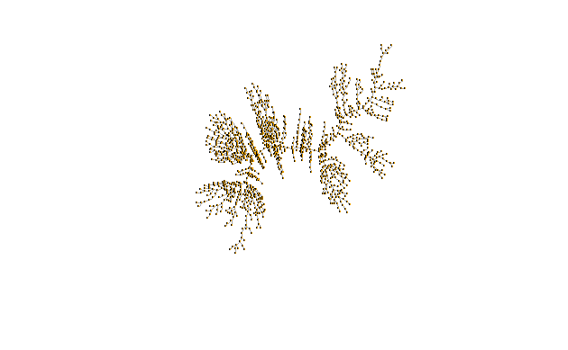

```r
position <- layout_with_kk(gmst)
plot(gmst, layout = position, vertex.label = NA, vertex.size = 1)
```

The result already revealed some branches and clusters, we could use this layout as an initial position and speed up the generation of `vizgraph` layout.

In this step, you would probably want to explore different layout algorithms, tune their parameters, and plot them until you get a satisfying position. Sometimes, it may require some manual adjustments before you finalize the layout.

The following use the initial position of the mst, and optimize the layout of the whole network.

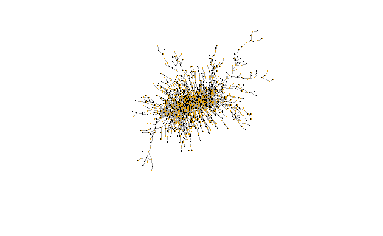

```r
position2 <- layout_with_kk(vizgraph, coords = position)
plot(vizgraph, layout = position2, vertex.label = NA, vertex.size = 1)
```

The position output is a matrix, we could create a dataframe and merge it with the nodedf for future use.

```r
nodedf <- nodedf %>% mutate(x = position2[, 1], y = position2[, 2])
head(nodedf)
```

| hs_product_code | hs_product_name_short_en | x | y |
| --- | --- | --- | --- |
| 0101 | Horses | 2.2868797 | -4.1998717 |
| 0102 | Bovine | 4.1788784 | 0.3696016 |
| 0103 | Swine | 0.2477504 | -2.1030794 |
| 0104 | Sheep | 8.0660799 | 2.0290384 |
| 0105 | Fowl | 1.2439072 | 2.2964814 |
| 0106 | Other live animals | 5.5179894 | -0.2366434 |

## Community detection

We would like to extract more meso-scale structural information out of this network representation, one option is to extract the community structure that reveal the block structure we saw in matrix plot.

There are a number of community detection algorithms. The Louvain algorithm is one of the most widely used solution, and `igraph` has a function `cluster_louvain` that implements the method.

```r
comm <- cluster_louvain(vizgraph)
length(comm)
```

```
[1] 41
```

We used the default parameter and get 41 communities.

The `comm` is a `communities` object. We could also add the id by `membership` function to the nodedf dataframe for further analysis.

```r
nodedf <- nodedf %>% mutate(communityid = membership(comm))
head(nodedf)
```

| hs_product_code | hs_product_name_short_en | x | y | communityid |
| --- | --- | --- | --- | --- |
| 0101 | Horses | 2.2868797 | -4.1998717 | 1 |
| 0102 | Bovine | 4.1788784 | 0.3696016 | 2 |
| 0103 | Swine | 0.2477504 | -2.1030794 | 3 |
| 0104 | Sheep | 8.0660799 | 2.0290384 | 4 |
| 0105 | Fowl | 1.2439072 | 2.2964814 | 5 |
| 0106 | Other live animals | 5.5179894 | -0.2366434 | 2 |

The size of each community is via `sizes` function:

```r
sizes(comm)
```

```
Community sizes
  1   2   3   4   5   6   7   8   9  10  11  12  13  14  15  16  17  18
 20 150 182  43  81  15  22  65  62  19  14  15   6 196  72   8   6  14
 19  20  21  22  23  24  25  26  27  28  29  30  31  32  33  34  35  36
 10  46   6   5   7   4   7  29   4   5   4   7   7   5  15  10  12  17
 37  38  39  40  41
  5  24   4  11   6
```

For each community, we could check the included products to understand its meaning.

For example, community 8 is a cluster of garments and textile products

```r
nodedf %>%
  filter(communityid == 8) %>%
  sample_n(15)
```

| hs_product_code | hs_product_name_short_en | x | y | communityid |
| --- | --- | --- | --- | --- |
| 6217 | Other clothing accesories | 3.263134 | 2.981230 | 8 |
| 2401 | Unmanufactured tobacco | 5.561894 | 1.743728 | 8 |
| 6115 | Socks, stockings, etc., knit | 3.161388 | 1.872391 | 8 |
| 6304 | Other furnishing articles | 5.354441 | 4.861087 | 8 |
| 1207 | Other oil seeds | 6.522265 | 2.687128 | 8 |
| 6202 | Womens overcoats, not knit | 4.387908 | 2.972270 | 8 |
| 1211 | Plants used in perfumery, pharmacy or insecticide | 5.928656 | 1.762838 | 8 |
| 6102 | Women's overcoats, knit | 3.784800 | 3.321827 | 8 |
| 6302 | House linen | 4.875506 | 3.727973 | 8 |
| 6104 | Women's suits, knit | 3.760261 | 2.956284 | 8 |

[output cut: 5 more lines]

Rearrange the rows and columns order, we see a clearer block structure in the matrxi view heatmap

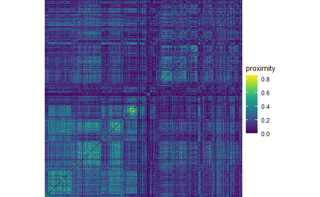

```r
orderbycomm <- (nodedf %>% arrange(communityid))$hs_product_code
ggplot(
  proxdf %>%
    mutate(
      commoditycode_1 = factor(commoditycode_1, levels = orderbycomm),
      commoditycode_2 = factor(commoditycode_2, levels = orderbycomm)
    ),
  aes(commoditycode_1, commoditycode_2, fill = proximity)
) +
  geom_raster() +
  coord_equal() +
  scale_fill_viridis() +
  theme_void()
```

## Mapping properties to aesthetic elements

Once we have fixed the position of nodes in the network, the aesthetic elements we could use are mainly the color and size of the nodes. Different shapes of the nodes are not very distinguishable with >1000 nodes, and labels are only usable to annotate few nodes/sectors/communities.

In this section, we will use a saved output from the atlas of economic complexity for 2015. You could create these files by following previousl tutorials, or running the `economiccomplexity` package and collect outputs.

```r
if (!file.exists("df_ec.tsv")) {
  download.file("https://www.dropbox.com/s/510nkpc7mwnjvbp/df_ec.tsv?dl=1", "df_ec.tsv")
}
df_ec <- read_tsv("df_ec.tsv")
head(df_ec)
```

| location_code | hs_product_code | export_value | year | diversity | ubiquity | mcp | eci | pci | density | coi | cog | rca | location_name_short_en | hs_product_name_short_en |
| --- | --- | --- | --- | --- | --- | --- | --- | --- | --- | --- | --- | --- | --- | --- |
| ABW | 0101 | 0 | 2015 | 25 | 20 | 0 | 0.2144563 | 0.3886628 | 0.02655988 | -0.7604919 | 0.31130923 | 0.0000000 | Aruba | Horses, asses, mules and hinnies; live |
| ABW | 0102 | 0 | 2015 | 25 | 44 | 0 | 0.2144563 | -0.2233603 | 0.02928137 | -0.7604919 | -0.03165201 | 0.0000000 | Aruba | Bovine animals; live |
| ABW | 0103 | 0 | 2015 | 25 | 19 | 0 | 0.2144563 | 1.9155664 | 0.02057430 | -0.7604919 | 0.68306766 | 0.0000000 | Aruba | Swine; live |
| ABW | 0104 | 0 | 2015 | 25 | 24 | 0 | 0.2144563 | -2.3840681 | 0.02090282 | -0.7604919 | -0.19851492 | 0.0000000 | Aruba | Sheep and goats; live |
| ABW | 0105 | 13182 | 2015 | 25 | 31 | 0 | 0.2144563 | 0.8045617 | 0.02534679 | -0.7604919 | 0.46274873 | 0.0394239 | Aruba | Poultry; live, fowls of the species gallus domesticus, ducks, geese, turkeys and guinea fowls |
| ABW | 0106 | 0 | 2015 | 25 | 63 | 0 | 0.2144563 | -2.1174390 | 0.03471172 | -0.7604919 | -0.37598589 | 0.0000000 | Aruba | Animals, n.e.s. in chapter 01; live |

### use ggraph

The aesthetic mapping could be done by manually creating vectors of color/shape/etc. as the input of `igrpah` plotting function. However, the more elegant and “tidy” flavor of graph ploting is to leverage the ability of `ggplot2` as a backend to do these mapping automatically. `ggraph` is a package that bridges the `ggplot2` system and graph object. There are other alternatives such as `ggnetwork` and `ggnet2`, but we will stick to the `ggraph` package hear for its rich features.

The following codes converts the `vizgraph` object into the `tbl_graph` object

```r
vizgg <- vizgraph %>% as_tbl_graph()
vizgg
```

```
# A tbl_graph: 1240 nodes and 3107 edges
#
# An undirected simple graph with 1 component
#
# Node Data: 1,240 x 2 (active)
  hs_product_name_short_en_1 name
  <chr>                      <chr>
1 Horses                     0101
2 Bovine                     0102
3 Swine                      0103
4 Sheep                      0104
5 Fowl                       0105
6 Other live animals         0106
# ... with 1,234 more rows
#
# Edge Data: 3,107 x 3
   from    to weight
  <int> <int>  <dbl>
1  1235  1237  0.5
2  1235  1236  0.5
3  1211  1226  0.545
# ... with 3,104 more rows
```

You can see the object is actually two dataframes that could be altered with tidy verbs. The following shows how to left join our generated community id to this object:

```r
vizgg <- vizgg %>%
  activate(nodes) %>%
  left_join(nodedf %>% select(hs_product_code, communityid), by = c("name" = "hs_product_code"))
vizgg
```

```
# A tbl_graph: 1240 nodes and 3107 edges
#
# An undirected simple graph with 1 component
#
# Node Data: 1,240 x 3 (active)
  hs_product_name_short_en_1 name  communityid
  <chr>                      <chr> <membrshp>
1 Horses                     0101  1
2 Bovine                     0102  2
3 Swine                      0103  3
4 Sheep                      0104  4
5 Fowl                       0105  5
6 Other live animals         0106  2
# ... with 1,234 more rows
#
# Edge Data: 3,107 x 3
   from    to weight
  <int> <int>  <dbl>
1  1235  1237  0.5
2  1235  1236  0.5
3  1211  1226  0.545
# ... with 3,104 more rows
```

Let’s use `ggplot2` style to plot this object with our generated layout `position2`, tune the theme:

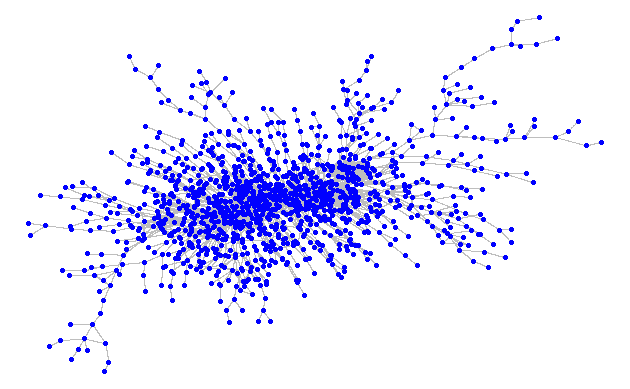

```r
vizgg %>% ggraph(layout = position2) +
  geom_edge_link(color = "grey") +
  geom_node_point(color = "blue") +
  theme_void()
```

### Color

The color of the nodes are usually used to indicate different categories, such as 2-digit sectors or the communities we discovered above.

A meaningful color map usually require some manual design, such as using brown to represent mining activities and products. Here we would just assign a color to each community without further improvement.

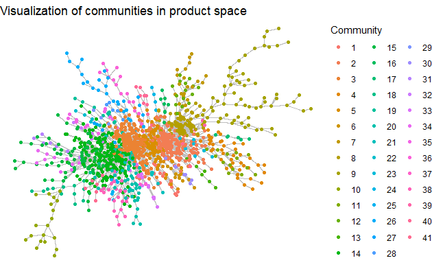

```r
vizgg %>% ggraph(layout = position2) +
  geom_edge_link(color = "grey") +
  geom_node_point(aes(color = factor(communityid))) +
  theme_void() +
  guides(color = guide_legend(title = "Community")) +
  ggtitle("Visualization of communities in product space")
```

### Size

We will use the node size to represent the PCI of each product, let’s extract the PCI and join the graph object:

```r
vizgg <- vizgg %>%
  activate(nodes) %>%
  left_join(df_ec %>% select("hs_product_code", "pci") %>% distinct(), by = c("name" = "hs_product_code"))
vizgg
```

```
# A tbl_graph: 1240 nodes and 3107 edges
#
# An undirected simple graph with 1 component
#
# Node Data: 1,240 x 4 (active)
  hs_product_name_short_en_1 name  communityid    pci
  <chr>                      <chr> <membrshp>   <dbl>
1 Horses                     0101  1            0.389
2 Bovine                     0102  2           -0.223
3 Swine                      0103  3            1.92
4 Sheep                      0104  4           -2.38
5 Fowl                       0105  5            0.805
6 Other live animals         0106  2           -2.12
# ... with 1,234 more rows
#
# Edge Data: 3,107 x 3
   from    to weight
  <int> <int>  <dbl>
1  1235  1237  0.5
2  1235  1236  0.5
3  1211  1226  0.545
# ... with 3,104 more rows
```

Here we specify the size should be mapped to pci, and the `scale_*` function could be used to tune details. Let’s save the object as `p` for further use

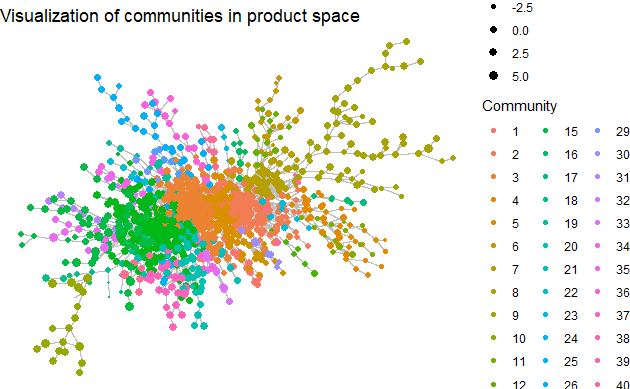

```r
p <- vizgg %>% ggraph(layout = position2) +
  geom_edge_link(color = "grey") +
  geom_node_point(aes(color = factor(communityid), size = pci)) +
  scale_size(range = c(0.1, 3)) +
  theme_void() +
  guides(color = guide_legend(title = "Community"), size = guide_legend(title = "Product complexity"))
p + ggtitle("Visualization of communities in product space")
```

### Annotation

Sometimes we would like to add some annotations to the product space visualization. Here we will first calculate the center of each community:

```r
df_anno <- nodedf %>%
  group_by(communityid) %>%
  summarise(x = mean(x), y = mean(y))
head(df_anno)
```

| communityid | x | y |
| --- | --- | --- |
| 1 | 1.8852725 | -4.57658954 |
| 2 | 3.4858269 | 0.23818788 |
| 3 | -0.6745119 | 0.57538081 |
| 4 | 9.2391431 | -1.19103115 |
| 5 | 1.4026211 | 0.08781609 |
| 6 | 3.7242639 | -3.38884437 |

Add the communityid to the center with `geom_text`. You could also annotate nodes based on your needs.

```
Warning: Removed 1 rows containing missing values (geom_point).
```

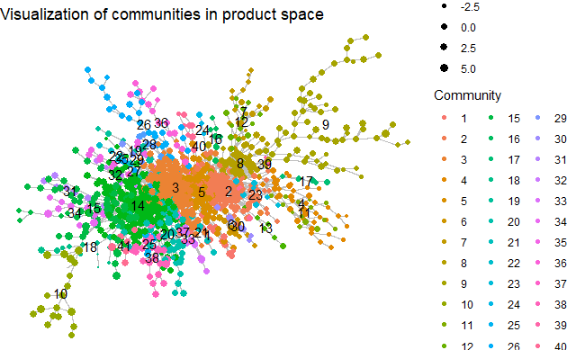

```r
p + geom_text(data = df_anno, aes(x, y, label = communityid)) +
  ggtitle("Visualization of communities in product space")
```

### Region specific plot

With the full product space, we can highlight the products with RCA>1 for a region. The following shows products of Japan in 2015.

```r
df_jpn <- df_ec %>%
  filter(location_code == "JPN") %>%
  select(hs_product_code, mcp)
df_jpn
```

| hs_product_code | mcp |
| --- | --- |
| 0101 | 0 |
| 0102 | 0 |
| 0103 | 0 |
| 0104 | 0 |
| 0105 | 0 |
| 0106 | 0 |
| 0201 | 0 |
| 0202 | 0 |
| 0203 | 0 |
| 0204 | 0 |

[output cut: 990 more lines]

Join the dataset with graph object

```r
vizjpn <- vizgg %>%
  activate(nodes) %>%
  left_join(df_jpn, by = c("name" = "hs_product_code"))
vizjpn
```

```
# A tbl_graph: 1240 nodes and 3107 edges
#
# An undirected simple graph with 1 component
#
# Node Data: 1,240 x 5 (active)
  hs_product_name_short_en_1 name  communityid    pci   mcp
  <chr>                      <chr> <membrshp>   <dbl> <dbl>
1 Horses                     0101  1            0.389     0
2 Bovine                     0102  2           -0.223     0
3 Swine                      0103  3            1.92      0
4 Sheep                      0104  4           -2.38      0
5 Fowl                       0105  5            0.805     0
6 Other live animals         0106  2           -2.12      0
# ... with 1,234 more rows
#
# Edge Data: 3,107 x 3
   from    to weight
  <int> <int>  <dbl>
1  1235  1237  0.5
2  1235  1236  0.5
3  1211  1226  0.545
# ... with 3,104 more rows
```

We could set the background layer as grey, and the node color that Japan doesn’t have comparative advantage has alpha=0.

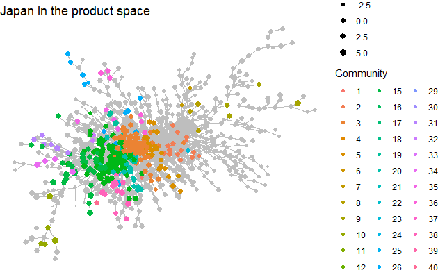

```r
vizjpn %>% ggraph(layout = position2) +
  geom_edge_link(color = "grey") +
  geom_node_point(aes(size = pci), color = "grey") +
  geom_node_point(aes(color = factor(communityid), size = pci, alpha = factor(mcp))) +
  scale_size(range = c(0.1, 3)) +
  scale_alpha_manual(values = c(0, 1), na.value = 0, guide = "none") +
  theme_void() +
  guides(color = guide_legend(title = "Community"), size = guide_legend(title = "Product complexity")) +
  ggtitle("Japan in the product space")
```

The visualization could be further improved with any `ggplot2` style tricks.

## Save the result for future use

After a series of operations, we finalized the visualization. It’s better to save them and prevent repeating the same process.

To save the plotting results, just use `ggsave`:

```r
ggsave("productspace.png", p)
```

```
Warning: Removed 1 rows containing missing values (geom_point).
```

Besides the visualization, you may also want to save the networks and node attributes dataframe, which helps you resume the analysis, or conduct analysis in other softwares. For example, save network into graphml format, and you could load it in Gephi for powerful plots.

```r
vizgraph %>% write_graph("productspace.graphml", format = "graphml")
```

## Why do we need the edges?

As you may have noticed, in the network visualization above, we specify the edges to be grey and did nothing else. Most of the manipulations are for the layout of nodes, the color and size of nodes, the alpha of nodes, etc.

If we ignore all the edges, and purely rely on the `nodedf`, we can still get reasonable plots as:

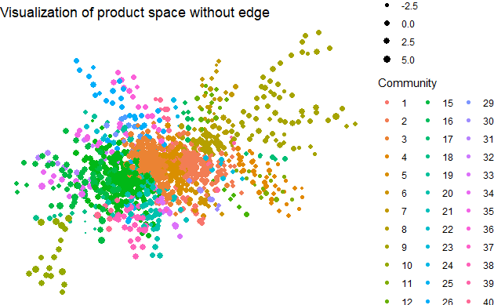

```r
nodedf <- nodedf %>%
  left_join(df_ec %>% select("hs_product_code", "pci") %>% distinct())
nodedf %>%
  ggplot(aes(x, y, color = factor(communityid), size = pci)) +
  geom_point() +
  scale_size(range = c(0.1, 3)) +
  theme_void() +
  guides(color = guide_legend(title = "Community"), size = guide_legend(title = "Product complexity")) +
  ggtitle("Visualization of product space without edge")
```

### UMAP visualization

We will follow the above idea and use the umap to generate the “layout” and do the visualization. The UMAP is already used in the [Metroverse](https://metroverse.cid.harvard.edu/) for the visualization of industry space

UMAP could calculate the distance metric from the raw data, or use the supplied distance matrix. Here we just use the same proximity matrix, and convert to a distance matrix:

```r
proxmat <- fullgraph %>% as_adj(attr = "proximity")
distmat <- as.matrix(1 - proxmat)
diag(distmat) <- 0
dim(distmat)
```

```
[1] 1240 1240
```

Use 5 nearest neighbors, and specify our input is a distance matrix to generate the UMAP embedding:

```r
umapres <- umap(distmat, input = "dist", n_neighbors = 5)
```

Extract the embedding/layout into the nodedf matrix:

```r
nodedf <- nodedf %>%
  mutate(umap_x = umapres$layout[, 1], umap_y = umapres$layout[, 2])
head(nodedf)
```

| hs_product_code | hs_product_name_short_en | x | y | communityid | pci | umap_x | umap_y |
| --- | --- | --- | --- | --- | --- | --- | --- |
| 0101 | Horses | 2.2868797 | -4.1998717 | 1 | 0.3886628 | -0.2148132 | 2.0085334 |
| 0102 | Bovine | 4.1788784 | 0.3696016 | 2 | -0.2233603 | -0.9766192 | 4.4221654 |
| 0103 | Swine | 0.2477504 | -2.1030794 | 3 | 1.9155664 | -0.8055132 | 0.7932237 |
| 0104 | Sheep | 8.0660799 | 2.0290384 | 4 | -2.3840681 | 0.5526700 | 2.1312773 |
| 0105 | Fowl | 1.2439072 | 2.2964814 | 5 | 0.8045617 | -1.8959960 | 3.1085898 |
| 0106 | Other live animals | 5.5179894 | -0.2366434 | 2 | -2.1174390 | 0.7064604 | 5.1555601 |

Generate visualization with the UMAP layout:

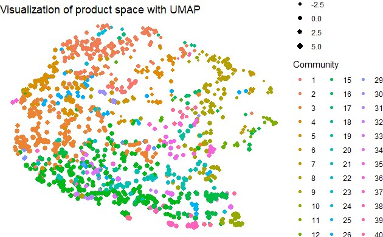

```r
nodedf %>%
  ggplot(aes(umap_x, umap_y, color = factor(communityid), size = pci)) +
  geom_point() +
  scale_size(range = c(0.1, 3)) +
  theme_void() +
  guides(color = guide_legend(title = "Community"), size = guide_legend(title = "Product complexity")) +
  ggtitle("Visualization of product space with UMAP")
```

The communities extracted from network method still have interpretable meaning with the UMAP. However, you could use various clustering tools now to generate different group divisions. A good choice would be some density based clustering method such as dbscan/hdbsan.